# 01 Vectors

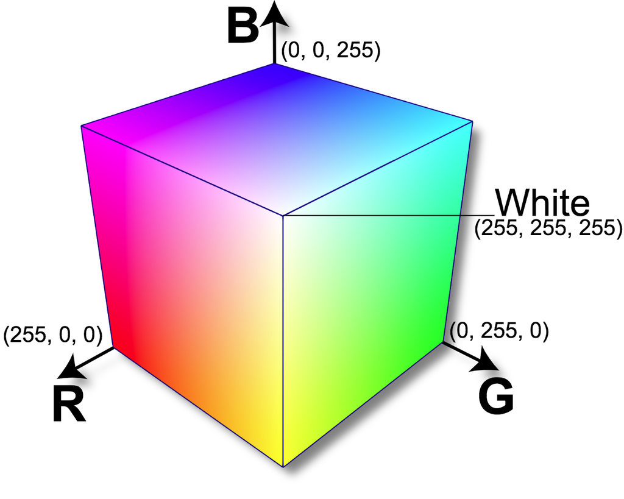

## Outline for ECE 3

#### Unit 1: Vectors, Book ILA Ch. 1-5

- *01 Vectors*
- 02 Linear Functions
- 03 Norms and Distances
- 04 Clustering
- 05 Linear Independence

#### Unit 2: Matrices, Book ILA Ch. 6-11 + Book IMC Ch. 2

#### Unit 3: Least Squares, Book ILA Ch. 12-14 + Book IMC Ch. 8

#### Unit 4: Eigen-decomposition, Book IMC Ch. 10, 12, 19

# Outline: 01 Vectors

- First definitions and notations
- Examples
- Addition, subtraction and scalar multiplication
- Inner product
- Complexity

# Outline: 01 Vectors

- **First definitions and notations**
- Examples
- Addition, subtraction and scalar multiplication
- Inner product
- Complexity

# Vector: Definition

$\color{#EF5645}{\text{Definition}}$ A *vector* is an ordered list of numbers, written as:

$$\begin{pmatrix} -1.1 \\ 0.0 \\ 3.6 \\ -7.2 \end{pmatrix} \text{ or } \begin{bmatrix} -1.1 \\ 0.0 \\ 3.6 \\ -7.2 \end{bmatrix} \text{ or } (-1.1, 0.0, 3.6, -7.2).$$

- The numbers in the list are called: *components, elements, entries, or coefficients* of the vector.
- The number $n$ of elements in the list is called: *size, dimension, or length* of the vector.
- If a vector has $n$ elements, it is called a $n$-vector.

$\color{#047C91}{\text{Exercise}}$: What are the components of the vector above? What is its dimension?

$\color{#EF5645}{\text{Definition}}$: In contrast to vectors, numbers are just called *scalars*. For example, 3.4 is a scalar.

# Vector: Notations

$\color{#EF5645}{\text{Notation}}$:

- We use symbols to denote vectors, e.g., $a, X, p, β, E^\text{aut}, \mathbf{g}, \overrightarrow{a}$.
- The ith element of $n$-vector $a$ is denoted $a_i$.
- In $a_i$, the $i$ is the index.

$\color{#EF5645}{\text{Remarks}}$: What is really "$a_i$"?

- in Math: for an n-vector, indexes run from $i = 1$ to $i = n$,
- 😱 in Python: for an n-vector, indexes run from $i = 0$ to $i = n - 1$,
- 😱 Sometimes, $a_i$ refers to the ith vector in a list of vectors.

$\color{#EF5645}{\text{Definition}}$: Two vectors a and b of the same size $n$ are equal if:

$$a_i = b_i \text{ for all $i$ in $\{1, ..., n\}$}.$$

# Vector: Python

$\color{#003660}{\text{In Python}}$, vectors can be represented as:

- a list of numbers, using `[]`,
- a tuple of numbers, using `()`,
- an array of numbers with the package [NumPy](https://numpy.org/).

```python
a = [-1.1, 0.0, 333.6, -7.2]; print(a)
b = (-1.1, 0.0, 3.6, -7.2); print(b)
```

```
[-1.1, 0.0, 333.6, -7.2]
(-1.1, 0.0, 3.6, -7.2)
```

```python
import numpy as np
c = np.array([-1.1, 0.0, 3.6, -7.2]); c
```

```
array([-1.1,  0. ,  3.6, -7.2])
```

The size/length/dimension of a vector is computed with `len`.

```python
len(a), len(b), len(c)
```

```
(4, 4, 4)
```

# Vector components: Python

$\color{#003660}{\text{In Python}}$, we can "access" the components of a vector with the following syntax.

```python
a[0], b[0], c[0]
```

```
(-1.1, -1.1, -1.1)
```

😱- Be careful that the first element is indexed 0, and the last is indexed n - 1.

```python
a[4]
```

```
---------------------------------------------------------------------------
IndexError                                Traceback (most recent call last)
/var/folders/dz/k1hb2xr94k558sjs416njdp40000gn/T/ipykernel_22722/3944406842.py in <module>
----> 1 a[4]

IndexError: list index out of range
```

# Vector components: Python

$\color{#003660}{\text{In Python}}$, the components of a vector can be "assigned" (except for the tuple 😱 ).

```python
a[2] = 4.0; c[2] = 4.0
print(a); c
```

```
[-1.1, 0.0, 4.0, -7.2]
```

```
array([-1.1,  0. ,  4. , -7.2])
```

```python
b[2] = 4.0
b
```

```
---------------------------------------------------------------------------
TypeError                                 Traceback (most recent call last)
/var/folders/dz/k1hb2xr94k558sjs416njdp40000gn/T/ipykernel_21476/1212393371.py in <module>
----> 1 b[2] = 4.0
      2 b

TypeError: 'tuple' object does not support item assignment
```

# 😱 Special Warning with NumPy Arrays

If we:

- assign a vector $a$ to another new vector $y$,
- change the components of $a$,

Then the components of $y$ will be changed.

The assignment of *arrays* does not copy the original array to a new one, it creates a *reference* to the same values.

```python
y = a; print(a, y)
y[2] = 666; print(a, y)
```

[output not shown]

To avoid this problem, use the `.copy` syntax:

```python
y = a.copy(); print(a, y)
a[3] = 202222; print(a, y)
```

[output not shown]

# Visualization of vectors

$\color{#003660}{\text{In Python}}$, we can use the package `matplotlib` to plot vectors.

The function `scatter` only plots a point that represents the end tip of the vector.

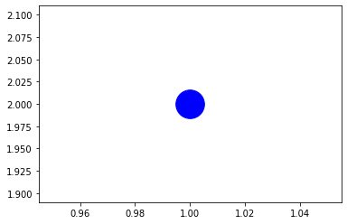

```python
import matplotlib.pyplot as plt

vector_2d = [1, 2]
plt.scatter(vector_2d[0], vector_2d[1], color='blue', s=1000);
```

The fonction `quiver` can actually plot a vector.

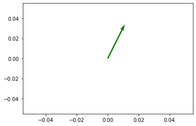

```python
origin = [0, 0]

plt.quiver(origin[0], origin[1], vector_2d[0], vector_2d[1], color='green', scale=10);
```

# Block or Stacked Vectors

$\color{#EF5645}{\text{Definition}}$: Suppose $a, b, c$ are vectors with sizes $m, n, p$. We can create a new vector $d$ as:

$$ d = \begin{bmatrix} a \\ b \\ c \end{bmatrix}.$$

The vector $d$ is called a *block vector or a stacked vector with entries $a, b, c$*, or simply the concatenation of $a, b, c$. $d$ has size $m+n+p$ with the following components:

$$d = (a_1, ..., a_m, b_1, ..., b_n, c_1, ..., c_p).$$

# Block or Stacked Vectors

$\color{#003660}{\text{In Python}}$, we can compute a block vector using `concatenate`.

```python
a = np.array([1, -1]); b = np.array([2, -2, -2.2]); c = np.array([3, 3.3])
d = np.concatenate([a, b, c]); d
```

```
array([ 1. , -1. ,  2. , -2. , -2.2,  3. ,  3.3])
```

# Zero, Ones and One-Hot Vectors

$\color{#EF5645}{\text{Definition}}$: The n-vector with all entries 0 is denoted $0_n$ or just $0$ and is called a zero vector. The n-vector with all entries 1 is denoted $1_n$ or just 1 and is called a ones-vector.

$\color{#EF5645}{\text{Definition}}$: A one-hot vector is a vector which has one entry 1 and all others 0. If $i$ is the index of the non-zero entry, we denote it $e_i$.

$\color{#047C91}{\text{Exercise}}$: What are all the one-hot vectors of length 3?

# Zero, Ones and One-Hot Vectors

$\color{#003660}{\text{In Python}}$:

```python
zeros_vec = np.zeros(3); display(zeros_vec)
ones_vec = np.ones(4); display(ones_vec)
```

```
array([0., 0., 0.])
```

```
array([1., 1., 1., 1.])
```

```python
i = 1; n = 3
ei = np.zeros(n); ei[i] = 1
ei
```

```
array([0., 1., 0.])
```

# Sparsity

$\color{#EF5645}{\text{Definition}}$: A vector is sparse if "many" of its entries are 0.

- Can be stored and manipulated efficiently on a computer.

$\color{#047C91}{\text{Exercise}}$: Give examples of sparse and non-sparse vectors.

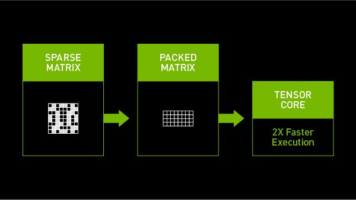

The A100 packs sparse matrices to accelerate AI inference tasks

# Outline: 01 Vectors

- First definitions and notations
- **Examples**
- Addition, subtraction and scalar multiplication
- Inner product
- Complexity

# Example: Location or displacement in 2D or 3D

The 2-vector $a=(a_1, a_2)$ can represent a location or a displacement in 2-D.

# Example: Color in RGB

The 3-vector $a$ can represent a color in RGB: $a = (R, G, B)$

[figure not shown]

The matrix coloring is an operation on vectors

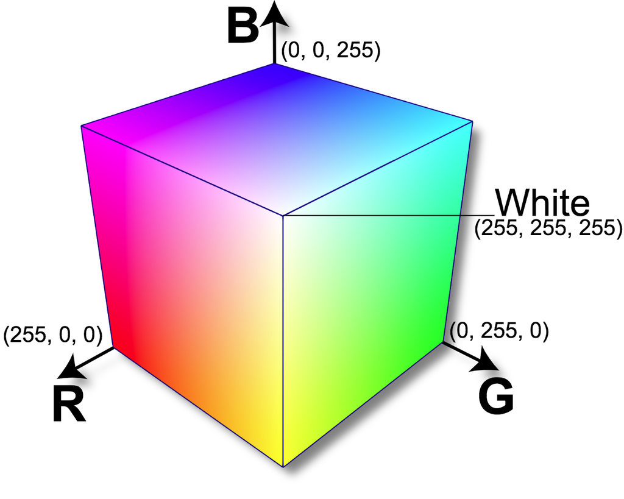

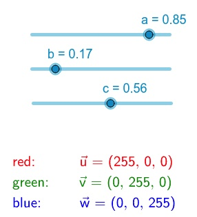

# Example: Word count vectors

The $n$-vector $a$ can represent the count of $n$ words in a given document.

In a short document:

*Word count vectors are used in computer based document analysis. Each entry of the word count vector is the number of times the associated dictionary word appears in the document.*

$\color{#047C91}{\text{Exercise}}$: Give the word count vector associated to the text in italic above using the following dictionnary:

$$D = \{\text{word, in, number, horse, the, document} \}.$$

# Other examples in ECE and beyond

- Education: Grades of n different exams
- Audio: $a_i$ is the acoustic pressure at sample time $i$ (sample times are spaced 1/44100 seconds apart)
- Deep Learning: Layers of a neural network

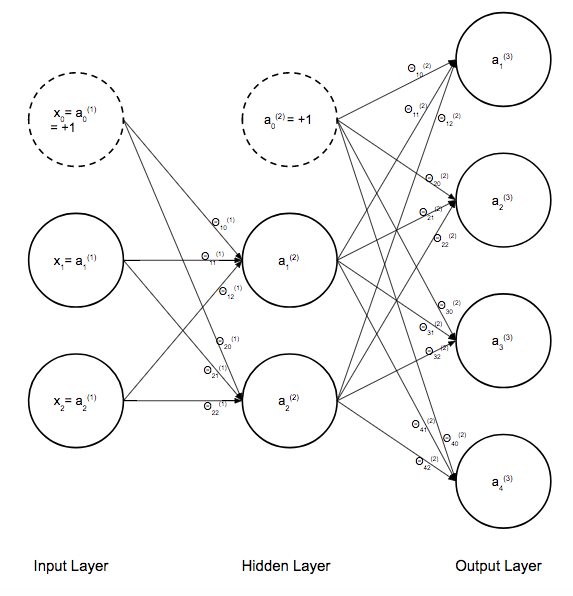

Each layer is represented as a vector in the computer.

# Outline: 01 Vectors

- First definitions and notations
- Examples
- **Addition, subtraction and scalar multiplication**
- Inner product
- Complexity

# Vector Addition and Subtraction

$\color{#EF5645}{\text{Definition}}$: Two (or more) n-vectors a and b can be added, with sum denoted a + b.

- The sum is computed by adding corresponding entries.
- Similary, a and b can be subtracted, with subtraction denoted a - b, and subtracting entries.

$\color{#047C91}{\text{Exercise}}$: Compute:

$$\begin{bmatrix} 0 \\ 7 \\ 3 \end{bmatrix} + \begin{bmatrix} 1 \\ 2 \\ 0 \end{bmatrix}$$

# Vector Addition and Subtraction

$\color{#003660}{\text{In Python}}$:

```python
a = np.array([0, 7, 3]) + np.array([1, 2, 0]); display(a)
a = np.array([1, 9]) - np.array([1, 1]); display(a)
```

```
array([1, 9, 3])
```

```
array([0, 8])
```

# Properties of Vector Addition

$\color{#6D7D33}{\text{Properties}}$: For any $n$-vectors $a, b$ we have:

- commutative: $a + b = b + a$
- associative: $(a + b) + c = a + (b + c) = a + b + c$
- $a + 0 = a$
- $a - a = 0$

# Adding displacement vectors

If vectors a and b are displacements, a + b is the sum displacement

# Displacement from one point to another

Displacement from point q to point p is p − q

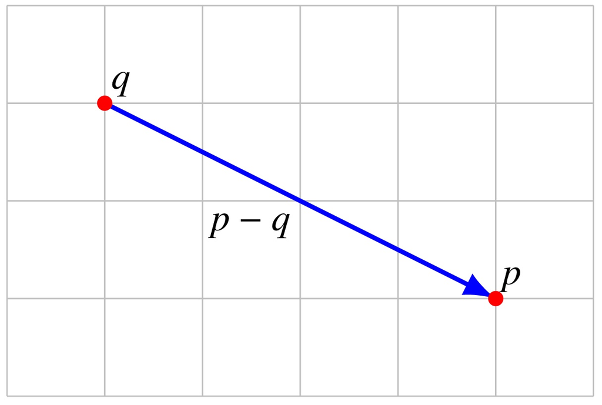

# Scalar-vector multiplication

$\color{#EF5645}{\text{Definition}}$: A scalar β and an $n$-vector a can be multiplied: $βa = ( βa_1, . . . , β a_n)$.

$\color{#047C91}{\text{Exercise}}$: Compute:

$$(-2) \begin{bmatrix} 1 \\ 9 \\ 6 \end{bmatrix}.$$

$\color{#003660}{\text{In Python}}$:

```python
x = np.array([0, 2, -1])
2.2 * x
```

```
array([ 0. ,  4.4, -2.2])
```

# Properties of scalar-vector multiplication

$\color{#6D7D33}{\text{Properties}}$: For scalars $\beta, \gamma$ and $n$-vectors $a, b$:

- associative: $( βγ)a = β(γa)$
- left distributive: $( β + γ)a = βa + γa$
- right distributive: $β(a + b) = βa + βb$

$\color{#003660}{\text{In Python}}$:

```python
a = np.array([1, 2]); b = np.array([3, 4]); beta = 0.5

lhs = beta * (a + b)
rhs = beta * a + beta * b
lhs, rhs
```

```
(array([2., 3.]), array([2., 3.]))
```

# Linear combinations

$\color{#EF5645}{\text{Definition}}$: For n-vectors $a_1, . . . , a_m$ and scalars $β_1, . . . , β_m$:

$$β_1a_1 + · · · + β_ma_m$$

is a linear combination of the vectors.

- $β_1, . . . , β_m$ are the coefficients.

$\color{#047C91}{\text{Exercise}}$: Write a $n$-vector $b = (b_1, ..., b_{n})$ as a linear combination of the one-hot n-vectors $e_1, ..., e_{n}$.

# Linear combinations

$\color{#003660}{\text{In Python}}$:

```python
a, b = np.array([1, 2]), np.array([3, 4])
alpha, beta = -.5, 1.5
alpha * a + beta * b
```

```
array([4., 5.])
```

# Displacements and Linear Combination

Two vectors $a_1$ and $a_2$, and linear combination $b = 0.75a_1 + 1.5a_2$

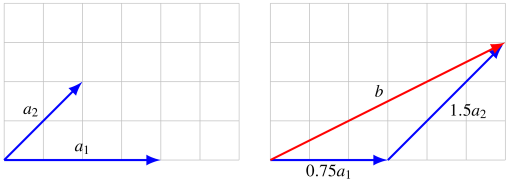

# Outline: 01 Vectors

- First definitions and notations
- Examples
- Addition, subtraction and scalar multiplication
- **Inner product**
- Complexity

# Inner Product

$\color{#EF5645}{\text{Definition}}$: The inner product (or dot product) of n-vectors a and b is $$a^T b = a_1b_1 + a_2b_2 + · · · + a_nb_n.$$

- Other notations: $〈a, b〉, 〈a|b〉, (a, b), a · b$.

$\color{#047C91}{\text{Exercise}}$: Compute the inner product of $a = (1, 0, 2)$ and $b = (-1, 1, 2)$.

$\color{#003660}{\text{In Python}}$:

```python
import numpy as np

x = np.array([-1, 2, 2])
y = np.array([1, 0, -3])
np.inner(x, y)
```

```
-7
```

# Properties of inner product

$\color{#6D7D33}{\text{Properties}}$: For $n$-vectors $a, b, c$ and scalars $\gamma$:

- $a^T b = b^T a$
- $(γa)^T b = γ(a^T b)$
- $(a + b)^T c = a^T c + b^T c$

$\color{#047C91}{\text{Exercise (at home)}}$:

- Show that for $n$-vectors $a, b, c, d$: $(a + b)^T (c + d) = a^T c + a^T d + b^T c + b^T d$
- Given $a = (a_1, ..., a_{n})$: compute $e_i^Ta$, $1^Ta$, $a^T a$ using the entries of $a$.

# Examples in ECE and beyond

- Education: $p$ grades, $q$ weights; $p^T q$ is the total grade
- Deep Learning:

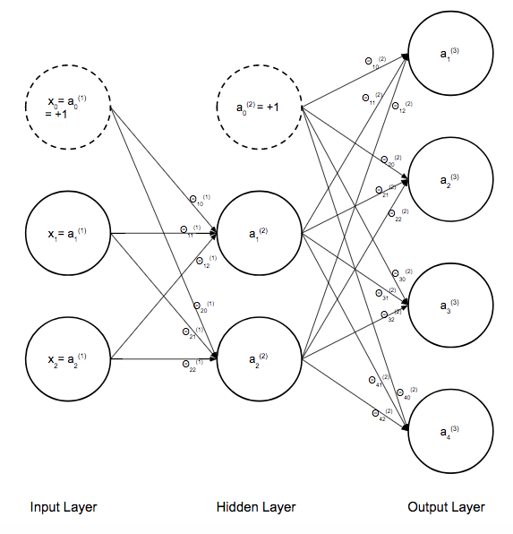

Inner product in neural networks.

# Outline: 01 Vectors

- First definitions and notations
- Examples
- Addition, subtraction and scalar multiplication
- Inner product
- **Complexity**

# Complexity = Flop Counts

Computers store (real) numbers in floating-point format.

```python
a = 1.4
type(a)
```

```
float
```

$\color{#EF5645}{\text{Definition}}$: Basic arithmetic operations (addition, multiplication, . . . ) are called floating point operations or flops.

# Complexity = Flop Counts

$\color{#EF5645}{\text{Definition}}$: The complexity of an algorithm or operation is the total number of flops needed, as function of the input dimension(s).

- Complexity allows to estimate the execution time: time to execute $\simeq$ (flops needed)/(computer speed)
- Current computers are around 1Gflop/sec ($10^9$ flop/sec)
- But the supercomputer can have many TeraFlop/sec ($10^{12}$ flop/sec)

[figure not shown]

Source: https://www.weforum.org/agenda/2021/01/supercomputer-world-technology-computer-japan-fugaku/

# Complexity of addition, inner product

For the $n$-vectors $x$ and $y$:

- $x + y$ needs $n$ additions, so: $n$ flops
- $x^T y$ needs $n$ multiplications and $n − 1$ additions so: $2n − 1$ flops --> approximated to $2n$

🤩 Much less flops are needed when $x$ or $y$ is sparse.

# Outline: 01 Vectors

- First definitions and notations
- Examples
- Addition, subtraction and scalar multiplication
- Inner product
- Complexity

# Resources

- Ch. 1 of Book ILA

```python
from IPython.display import Audio,Image, YouTubeVideo
id='fNk_zzaMoSs'
YouTubeVideo(id=id,width=600,height=300)
```

[video not shown]